# Explore the factors affecting the attrition & How to stay competitive in the job search

### Data understanding

- Education : *1 'Below College' 2 'College' 3 'Bachelor' 4 'Master' 5 'Doctor'*
- EnvironmentSatisfaction: *1 'Low'2 'Medium'3 'High'4 'Very High'*
- JobInvolvement: *1 'Low'2 'Medium'3 'High'4 'Very High'*
- JobSatisfaction: *1 'Low'2 'Medium'3 'High'4 'Very High'*
- PerformanceRating: *1 'Low'2 'Good'3 'Excellent'4 'Outstanding'*
- RelationshipSatisfaction: *1 'Low'2 'Medium'3 'High'4 'Very High'*
- WorkLifeBalance:

  *1 'Bad'2 'Good'3 'Better'4 'Best'*

**Statistical non-numerical data:**

- Attrition object,
- BusinessTravel object,
- Department object,
- EducationField object,
- Gender object,
- JobRole object,
- MaritalStatus object,
- Over18 object,
- OverTime object

```python
df.dtypes
```

```
Age                          int64
Attrition                   object
BusinessTravel              object
DailyRate                    int64
Department                  object
DistanceFromHome             int64
Education                    int64
EducationField              object
EmployeeCount                int64
EmployeeNumber               int64
EnvironmentSatisfaction      int64
Gender                      object
HourlyRate                   int64
JobInvolvement               int64
JobLevel                     int64
JobRole                     object
JobSatisfaction              int64
MaritalStatus               object
MonthlyIncome                int64
MonthlyRate                  int64
NumCompaniesWorked           int64
Over18                      object
OverTime                    object
PercentSalaryHike            int64
PerformanceRating            int64
RelationshipSatisfaction     int64
StandardHours                int64
StockOptionLevel             int64
TotalWorkingYears            int64
TrainingTimesLastYear        int64
WorkLifeBalance              int64
YearsAtCompany               int64
YearsInCurrentRole           int64
YearsSinceLastPromotion      int64
YearsWithCurrManager         int64
dtype: object
```

```python
select=['Attrition' ,'BusinessTravel' ,'Department' ,'EducationField' ,'Gender' ,'JobRole' ,'MaritalStatus' ,'Over18' ,'OverTime']
df[select].head()
```

|  | Attrition | BusinessTravel | Department | EducationField | Gender | JobRole | MaritalStatus | Over18 | OverTime |
| --- | --- | --- | --- | --- | --- | --- | --- | --- | --- |
| 0 | Yes | Travel_Rarely | Sales | Life Sciences | Female | Sales Executive | Single | Y | Yes |
| 1 | No | Travel_Frequently | Research & Development | Life Sciences | Male | Research Scientist | Married | Y | No |
| 2 | Yes | Travel_Rarely | Research & Development | Other | Male | Laboratory Technician | Single | Y | Yes |
| 3 | No | Travel_Frequently | Research & Development | Life Sciences | Female | Research Scientist | Married | Y | Yes |
| 4 | No | Travel_Rarely | Research & Development | Medical | Male | Laboratory Technician | Married | Y | No |

#### Understand the data range

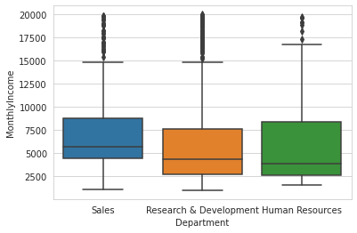

```python
dm=df[['Department','MonthlyIncome']]
ax1 = sns.boxplot(x="Department", y="MonthlyIncome", data=dm)
```

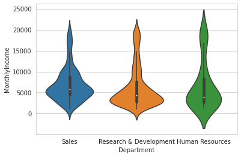

```python
ax2 = sns.violinplot(x="Department", y="MonthlyIncome", data=dm)
```

#### Understand the relationships between data

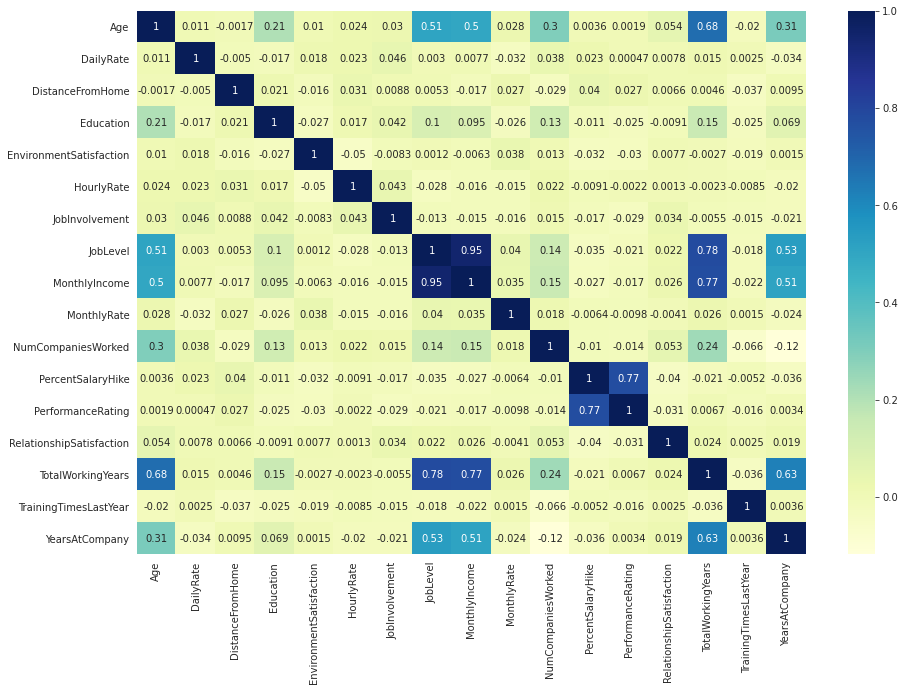

```python
corrMatrix=df[['Age', 'Attrition', 'BusinessTravel', 'DailyRate', 'Department','DistanceFromHome', 'Education', 'EducationField','EnvironmentSatisfaction', 'Gender', 'HourlyRate','JobInvolvement', 'JobLevel', 'JobRole',\
       'MaritalStatus', 'MonthlyIncome', 'MonthlyRate', 'NumCompaniesWorked','Over18', 'OverTime', 'PercentSalaryHike', 'PerformanceRating','RelationshipSatisfaction', 'TotalWorkingYears', 'TrainingTimesLastYear', 'YearsAtCompany']].select_dtypes(include=['float64','int64']).corr()
plt.figure(figsize=(15, 10))
sns.heatmap(corrMatrix, cmap="YlGnBu",annot=True)
```

### Data Cleaning

```python
df.fillna(method='ffill')
df.dropna(inplace=True)
df.drop_duplicates()
df.shape
```

```
(1470, 35)
```

## Explore the causes of employee attrition for enterprises

### What are the Department & MonthlyIncome impact on Attrition?

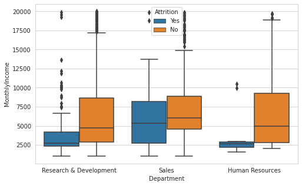

```python
dma=df[['Department','MonthlyIncome','Attrition']]
plt.figure(figsize=(8,5))
ax = sns.boxplot(x="Department", y="MonthlyIncome", hue="Attrition",data=dma,linewidth=1.5,order=["Research & Development", "Sales",'Human Resources'])
plt.show()
```

*conclusion:* It can be seen that the people who choose to quit work are mainly in the Sales Department. For them, the monthly salary has little impact, while for the people who quit work in the other two departments, it can be seen that the monthly salary is relatively low, which is the reason for their resignation.It is suggested that the company can appropriately raise the salaries of these two departments. **(๑•̀ㅂ•́)و✧**

### What are the JobRole & Age impact on Attrition?

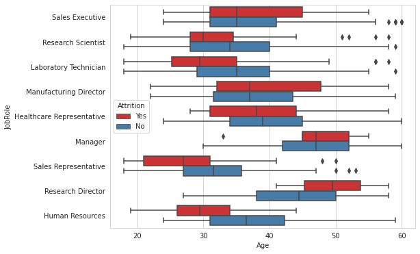

```python
plt.figure(figsize=(8,6))
jaa=df[['JobRole','Age','Attrition']]
ax = sns.boxplot(x="Age", y="JobRole", hue="Attrition",data=jaa,linewidth=1.5, palette="Set1",orient="h")
plt.show()
```

*conclusion:* It can be seen the staff quiting work of whoes job function is sales representative or human resources,they are younger. While most of the dimission personnel of manager and research director are older, and the age of the dimission personnel of the remaining departments is in the middle.So it is recommended that companies pay more attention to what is happening to young people in these two sectors (sales & human)and to what is happening to older people in (manager & research director).╰(*°▽°*)╯

### What are the MonthlyIncome & Gender & MaritalStatus impact on Attrition?

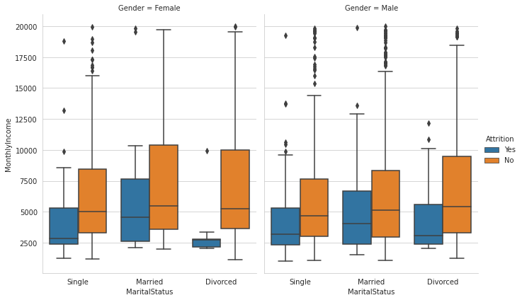

```python
amg=df[['Attrition','MonthlyIncome','Gender','MaritalStatus']]
ax= sns.catplot(x="MaritalStatus", y="MonthlyIncome",hue="Attrition", col="Gender",data=amg, kind="box",height=6, aspect=.8);
```

*conclusion*:It can be seen that both men and women, low salary is a major factor affecting the departure,and the number of married people who left the workforce was the highest. Most intriguingly, divorced women are among the least likely to leave, and companies can be tempted to hire them if they want to retain talent.┑(￣Д ￣)┍

### What are the MonthlyIncome & OverTime impact on Attrition? (Explore only the low-paid)

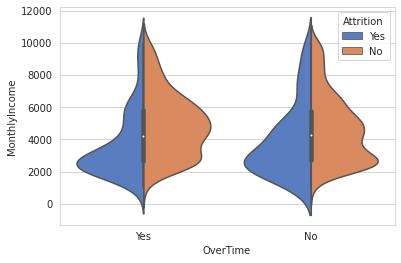

```python
ax = sns.violinplot(x="OverTime", y="MonthlyIncome",hue="Attrition",split=True,data=df[df.MonthlyIncome < 10000],scale="width", palette="muted")
```

*conclusion*: It can be seen that whether or not overtime work has little impact on the dimission. What is interesting is whether overtime work will affect the dimission of this group of people with a monthly income of about 6000. Σ( ° △ °|||)︴

### What are the NumCompaniesWorked & BusinessTravel impact on Attrition?

```python
bt = df[["BusinessTravel","Attrition"]]
bt=bt.groupby(["BusinessTravel","Attrition"]).size().reset_index()
#bt=DataFrame(bt,index=['Non-Travel-N', 'Non-Travel-Y', 'Travel_Frequently-N', 'Travel_Frequently-Y','Travel_Rarely-N','Travel_Rarely-Y'],columns=("BusinessTravel","Attrition",'count'))
bt.rename(columns={0:'Count'},index={0:'Non-Travel-N',1:'Non-Travel-Y', 2:'Travel_Frequently-N', 3:'Travel_Frequently-Y',4:'Travel_Rarely-N',5:'Travel_Rarely-Y'},inplace=True)
bt
```

|  | BusinessTravel | Attrition | Count |
| --- | --- | --- | --- |
| Non-Travel-N | Non-Travel | No | 138 |
| Non-Travel-Y | Non-Travel | Yes | 12 |
| Travel_Frequently-N | Travel_Frequently | No | 208 |
| Travel_Frequently-Y | Travel_Frequently | Yes | 69 |
| Travel_Rarely-N | Travel_Rarely | No | 887 |
| Travel_Rarely-Y | Travel_Rarely | Yes | 156 |

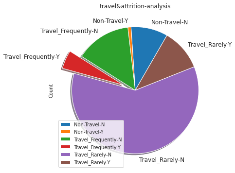

```python
bt.plot(kind='pie',y='Count',figsize=(6,6),title='travel&attrition-analysis',fontsize=12,explode=[0,0,0,0.2,0,0],shadow=True,startangle=60)
```

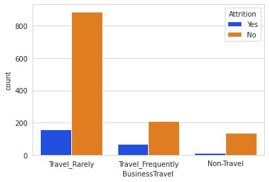

```python
ax = sns.countplot(x="BusinessTravel", hue="Attrition", data=df,palette="bright")
```

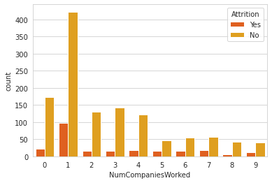

```python
ax = sns.countplot(x="NumCompaniesWorked", hue="Attrition", data=df,palette="autumn")
```

## Explore what factors influence being a competitive employee (as measured by salary)

### What is the Age impact on MonthlyIncome?

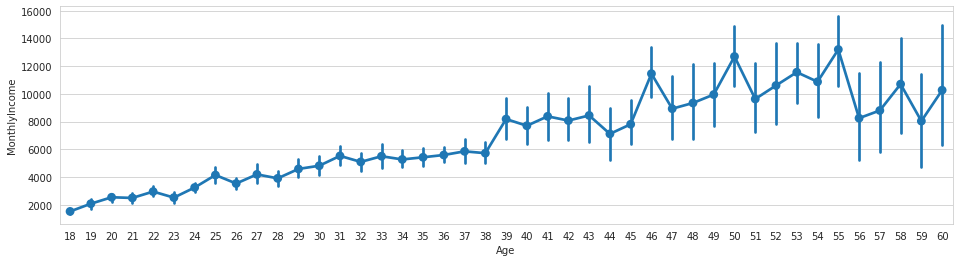

```python
plt.figure(figsize=(16,4))
sns.pointplot(x="Age",y="MonthlyIncome",data=df)# average income
plt.show()
```

*conclusion*: As you get older, wages will get higher, but the gap will widen, so young people entering the workforce should try to choose positions with high potential and pay less attention to the return on their salaries.(๑•̀ㅂ•́)و✧

### What is the JobRole impact on MonthlyIncome?

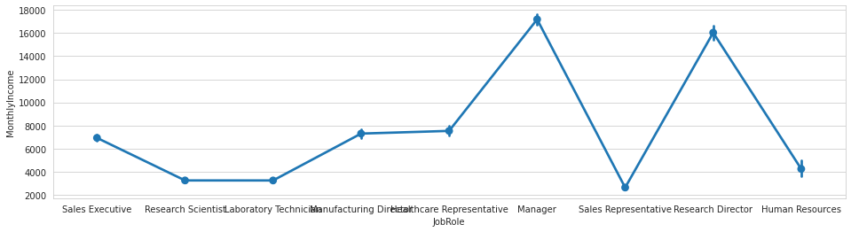

```python
plt.figure(figsize=(16,4))
sns.pointplot(x="JobRole",y="MonthlyIncome",data=df)#average income
plt.show()
```

### What is the TotalWorkingYears impact on MonthlyIncome?

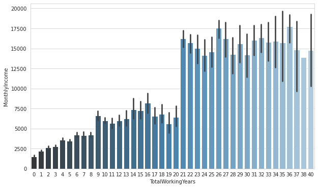

```python
plt.figure(figsize=(10,6))
ax = sns.barplot(x="TotalWorkingYears", y="MonthlyIncome", data=df, palette="Blues_d")
plt.show()
```

*conclusion:* We can see a significant change from 20 to 21 years of service, a significant increase in wages.So in the early stage of the workplace to accumulate enough experience, do not give up easily, work 20 years after the ability to see significant changes.(⊙﹏⊙)

### What is the EducationField impact on MonthlyIncome?

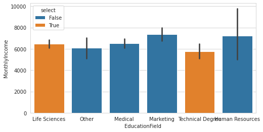

```python
plt.figure(figsize=(8,4))
df["select"] = df["EducationField"].isin(["Technical Degree", "Life Sciences"])
ax = sns.barplot(x="EducationField", y="MonthlyIncome", hue="select",\
                 data=df, dodge=False)
plt.show()
```

### What are the Department & Gender impact on MonthlyIncome?

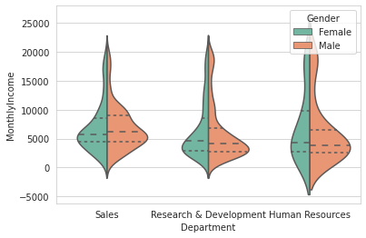

```python
ax = sns.violinplot(x="Department", y="MonthlyIncome", hue="Gender",data=df, palette="Set2", split=True,scale="count", inner="quartile")
```

*conclusion:* Generally speaking, there are a little more men than women in all sectors, but gender has little impact on salary, which indicates that there is no gender discrimination in this company.In the largest segment, employees working in sales are paid the most. o( =•ω•= )m

## Conclusion

In this project, I solved the problems of the company and its employees through data collation and visualization.For the company's human resources management department staff have certain inspiration.For employees, it is extremely important to reasonably plan their career steps, which can play a guiding role for those who are about to get employed or have been employed.